#Which year has the most jailed person in Del Norte County in CA

most_jailed_year <- incarceration_data %>% filter(county_name == “Del Norte County”, state == “CA”) %>% filter(total_jail_pop == max(total_jail_pop))

#what is the average jailed populations in 2005?

ave_jailed_2005 <- incarceration_data %>% filter(year == 2005) %>% summarize(mean(total_jail_pop, na.rm = TRUE))

#What is the total jailed populations in 2005 in Del Norte County in CA

total_jailed_Del <- most_jailed_year$total_jail_pop

#What is the proportion of black people jailed in 2005 in Del Norte County in CA

prop_black_person <- most_jailed_year$black_jail_pop/total_jailed_Del

#What is the proportion of white people jailed in 2005 in Del Norte County in CA

prop_white_person <- most_jailed_year$white_jail_pop/total_jailed_Del

#What is the rate of change in black people during 2000 to 2010 in Del Norte #County in CA

black_2000 <- incarceration_data %>% filter(year == 2000, county_name == “Del Norte County”, state == “CA”) %>% pull(black_jail_pop) black_2010 <- incarceration_data %>% filter(year ==2010, county_name == “Del Norte County”, state == “CA”) %>% pull(black_jail_pop) roc_black_Del <- (black_2010-black_2000)/black_2000

#What is the rate of change in white people during 2000 to 2010 in Del Norte #County in CA

white_2000 <- incarceration_data %>% filter(year == 2000, county_name == “Del Norte County”, state == “CA”) %>% pull(white_jail_pop) white_2010 <- incarceration_data %>% filter(year ==2010, county_name == “Del Norte County”, state == “CA”) %>% pull(white_jail_pop) roc_white_Del <- (white_2010-white_2000)/white_2000

# *Incarceration Report*

```r
source("../source/analysis.R")
```

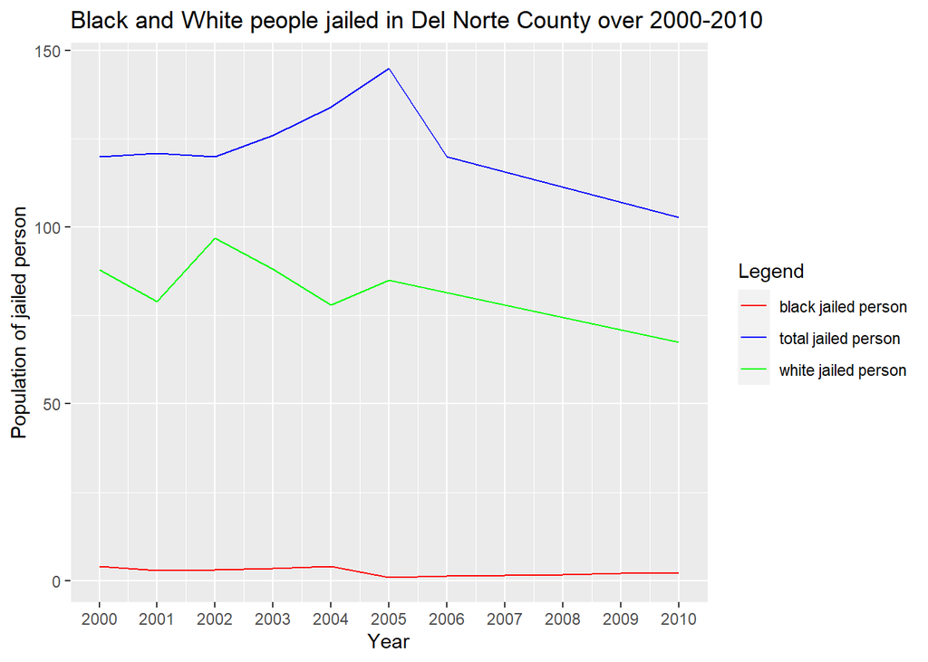

```r
trends_over_time_chart
```

## *Chart 1 Summary:*

I included this chart because I believe the trends could show important information of how the population of jailed person has increased or decreased throughout the years. There are three variables: black jailed person, white jailed person and total jailed person. The horizontal axis is the years, ranging from 2000 to 2010. The vertical axis is the population of jailed person. With the years displayed, we could easily view the trend of the population of jailed person each year.I discovered from the graph that in this Del Norte County, White jailed people is occupying a large portion of the total jailed people. Black jailed people are only a small portion.

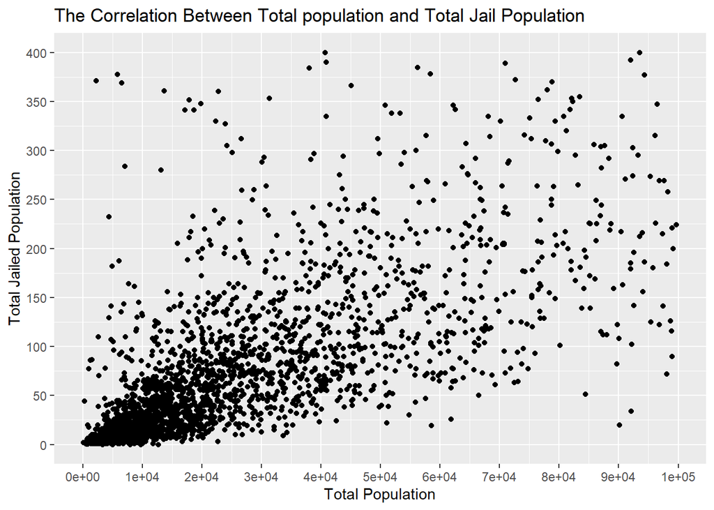

```r
two_variable_chart
```

## *Chart 2 Summary:*

The second chart I created could show the comparison between the total population and the total jailed population. The reason why I included it is due to the reason that I assumed a positive correlation between the total population of a county and the total jailed population in a county. I would like to check whether my hypothesis is correct. In this chart, I could definitely see that as the total population grows, the total jailed population grows as well. So there’s a positive correlation between those two variables.

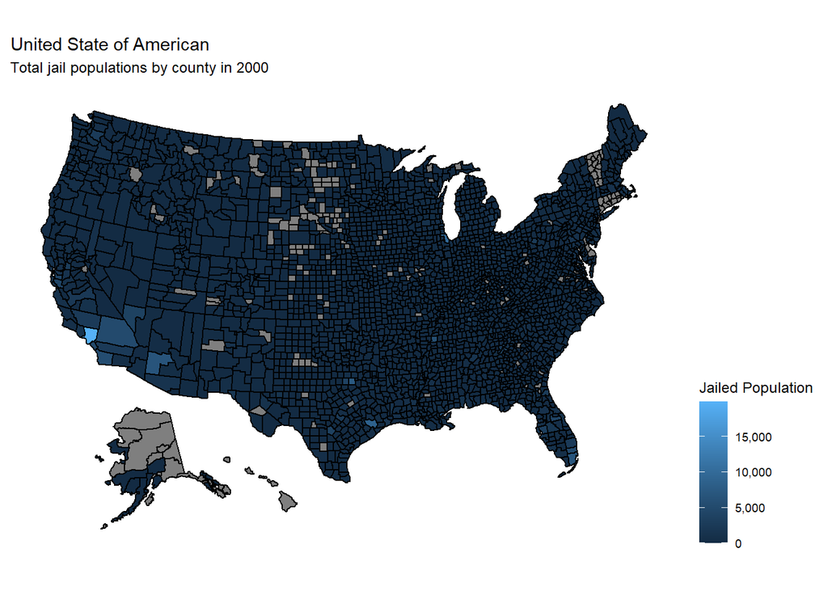

```r
Map
```

## *Map Summary:*

I included this graph because this map could clearly show the different jailed populations in each county. The darker the color the less jailed population there is. The greyish color means that there’s no data corresponding with the county. We could see that most counties are dark blue, meaning that they have ery little jailed population within.